# Projekt iz kolegija Statistička analiza podataka

```r
t.test(kor_test_data$GDP_GROWTH, nor_test_data$GDP_GROWTH, alternative = 'greater', var.equal = T)
```

```
##
##  Two Sample t-test
##
## data:  kor_test_data$GDP_GROWTH and nor_test_data$GDP_GROWTH
## t = 1.9978, df = 76, p-value = 0.02466
## alternative hypothesis: true difference in means is greater than 0
## 95 percent confidence interval:
##  0.004030151         Inf
## sample estimates:
##  mean of x  mean of y
## 0.08698283 0.06277968
```

```r
t.test(kor_test_data$GDP_GROWTH, usa_test_data$GDP_GROWTH, alternative = 'greater', var.equal = F)
```

```
##
##  Welch Two Sample t-test
##
## data:  kor_test_data$GDP_GROWTH and usa_test_data$GDP_GROWTH
## t = 3.6283, df = 54.999, p-value = 0.0003129
## alternative hypothesis: true difference in means is greater than 0
## 95 percent confidence interval:
##  0.01751998        Inf
## sample estimates:
##  mean of x  mean of y
## 0.08698283 0.05447202
```

```r
t.test(nor_test_data$GDP_GROWTH, usa_test_data$GDP_GROWTH, alternative = 'greater', var.equal = F)
```

```
##
##  Welch Two Sample t-test
##
## data:  nor_test_data$GDP_GROWTH and usa_test_data$GDP_GROWTH
## t = 0.84283, df = 51.763, p-value = 0.2016
## alternative hypothesis: true difference in means is greater than 0
## 95 percent confidence interval:
##  -0.008200879          Inf
## sample estimates:
##  mean of x  mean of y
## 0.06277968 0.05447202
```

```r
t.test(aus_test_data$EXPORT_GROWTH, aus_test_data$IMPORT_GROWTH, alternative = 'greater', paired = T, var.equal = F)
```

```
##
##  Paired t-test
##
## data:  aus_test_data$EXPORT_GROWTH and aus_test_data$IMPORT_GROWTH
## t = -0.89125, df = 38, p-value = 0.8108
## alternative hypothesis: true difference in means is greater than 0
## 95 percent confidence interval:
##  -0.03489003         Inf
## sample estimates:
## mean of the differences
##              -0.0120657
```

```r
t.test(kor_test_data$EXPORT_GROWTH, kor_test_data$IMPORT_GROWTH, alternative = 'greater', paired = T, var.equal = T)
```

```
##
##  Paired t-test
##
## data:  kor_test_data$EXPORT_GROWTH and kor_test_data$IMPORT_GROWTH
## t = 1.2705, df = 38, p-value = 0.1058
## alternative hypothesis: true difference in means is greater than 0
## 95 percent confidence interval:
##  -0.006033397          Inf
## sample estimates:
## mean of the differences
##              0.01845319
```

```r
t.test(nor_test_data$EXPORT_GROWTH, nor_test_data$IMPORT_GROWTH, alternative = 'greater', paired = T, var.equal = T)
```

```
##
##  Paired t-test
##
## data:  nor_test_data$EXPORT_GROWTH and nor_test_data$IMPORT_GROWTH
## t = -0.57161, df = 38, p-value = 0.7145
## alternative hypothesis: true difference in means is greater than 0
## 95 percent confidence interval:
##  -0.0196199        Inf
## sample estimates:
## mean of the differences
##            -0.004967719
```

```r
t.test(usa_test_data$EXPORT_GROWTH, usa_test_data$IMPORT_GROWTH, alternative = 'greater', paired = T, var.equal = T)
```

```
##
##  Paired t-test
##
## data:  usa_test_data$EXPORT_GROWTH and usa_test_data$IMPORT_GROWTH
## t = -0.38863, df = 38, p-value = 0.6501
## alternative hypothesis: true difference in means is greater than 0
## 95 percent confidence interval:
##  -0.02126128         Inf
## sample estimates:
## mean of the differences
##             -0.00398288
```

Testiranjem smo dobili kako pri razini značajnosti of 5% ne možemo odbaciti nultu hipotezu da je rast izvoza manji ili jednak od rasta uvoza.

I naposljetku, ispitujemo povezanost rasta BDP-a i BDP-a po glavi stanovnika. Budući da smo ranije pokazali kako ove populacije nemaju normalnu razdiobu, trebali bismo koristiti neparametarske testove. No, budući da koristimo uzorak veličine 39, po graničnom centralnom teoremu (CGT) možemo zanemariti nepostojanje normalne distribucije i koristiti aproksimiranje na normalnu distribuciju. Dakle, možemo provesti upareni t test budući da su podaci međusobno zavisni. Dodatno kao provjeru provodimo i njegovu neparametarsku alternativu, odnosno Wilcoxonov test.

```r
t.test(aus_test_data$GDP_GROWTH, aus_test_data$GDP_PER_CAPITA_GROWTH, var.equal = F, paired = T)
```

```
##
##  Paired t-test
##
## data:  aus_test_data$GDP_GROWTH and aus_test_data$GDP_PER_CAPITA_GROWTH
## t = 29.563, df = 38, p-value < 2.2e-16
## alternative hypothesis: true difference in means is not equal to 0
## 95 percent confidence interval:
##  0.01349020 0.01547354
## sample estimates:
## mean of the differences
##              0.01448187
```

```r
wilcox.test(aus_test_data$GDP_GROWTH, aus_test_data$GDP_PER_CAPITA_GROWTH, paired=T)
```

```
##
##  Wilcoxon signed rank test
##
## data:  aus_test_data$GDP_GROWTH and aus_test_data$GDP_PER_CAPITA_GROWTH
## V = 780, p-value = 3.638e-12
## alternative hypothesis: true location shift is not equal to 0
```

```r
t.test(kor_test_data$GDP_GROWTH, kor_test_data$GDP_PER_CAPITA_GROWTH, paired = T)
```

```
##
##  Paired t-test
##
## data:  kor_test_data$GDP_GROWTH and kor_test_data$GDP_PER_CAPITA_GROWTH
## t = 13.625, df = 38, p-value = 3.322e-16
## alternative hypothesis: true difference in means is not equal to 0
## 95 percent confidence interval:
##  0.007615458 0.010273276
## sample estimates:
## mean of the differences
##             0.008944367
```

```r
t.test(nor_test_data$GDP_GROWTH, nor_test_data$GDP_PER_CAPITA_GROWTH, paired = T)
```

```
##
##  Paired t-test
##
## data:  nor_test_data$GDP_GROWTH and nor_test_data$GDP_PER_CAPITA_GROWTH
## t = 13.686, df = 38, p-value = 2.888e-16
## alternative hypothesis: true difference in means is not equal to 0
## 95 percent confidence interval:
##  0.006106251 0.008226328
## sample estimates:
## mean of the differences
##             0.007166289
```

```r
t.test(usa_test_data$GDP_GROWTH, usa_test_data$GDP_PER_CAPITA_GROWTH, paired = T, var.equal = F)
```

```
##
##  Paired t-test
##
## data:  usa_test_data$GDP_GROWTH and usa_test_data$GDP_PER_CAPITA_GROWTH
## t = 30.743, df = 38, p-value < 2.2e-16
## alternative hypothesis: true difference in means is not equal to 0
## 95 percent confidence interval:
##  0.009425557 0.010754400
## sample estimates:
## mean of the differences
##              0.01008998
```

```r
wilcox.test(usa_test_data$GDP_GROWTH, usa_test_data$GDP_PER_CAPITA_GROWTH, paired = T)
```

```
##
##  Wilcoxon signed rank test
##
## data:  usa_test_data$GDP_GROWTH and usa_test_data$GDP_PER_CAPITA_GROWTH
## V = 780, p-value = 3.638e-12
## alternative hypothesis: true location shift is not equal to 0
```

Zaključujemo kako u pravilu ne vrijedi da su rast BDP-a i rast BDP-a po glavi stanovništva značajno isti.

## *Linearna regresija*

Iako smo spomenuli kako se BDP izračunava po formuli u kojoj ovisi o 4 različite varijable, testirali smo različite modele koji su modelirali vezu između uvoza i izvoza te BDP-a.

Isti modeli nisu davali dobru aproksimaciju za sve države. Za svaku državu odabrali jedan ili dva modela za koje smo dobili dobre rezultate. Te iste modele smo i prikazali grafički (crne točkice - stvarna vrijednost, plava linija - fittana vrijednost). Dodatno smo još testirali i normalnost reziduala putem QQ grafa i Kolmogorov-Smirnovljev testa. Sama funkcija modela linearne regresije već ima implementirane podatke o vrijednosti F statistike koja nam govori o signifikantnosti modela, ali i o vrijednosti koeficijenta determinancije. Nulta hipoteza Kolmogorov-Smirnovljeva testa govori kako je distribucija uzorka normalna distribucija. S druge strane, alternativna H1 hipoteza govori kako distribucija uzorka nije normalna. Uz nivo značajnosti od 5%, nultu hipotezu odbacujemo ukoliko je p-vrijednost testa manja od 5%.

**Australija**

```r
lm.data <- sap.data %>% filter(LOCATION=="AUS")

lm1 <- lm(GDP ~ EXPORT + IMPORT, lm.data)
summary(lm1)
```

```
##
## Call:
## lm(formula = GDP ~ EXPORT + IMPORT, data = lm.data)
##
## Residuals:
##    Min     1Q Median     3Q    Max
## -50573 -12320   1293  15875  59758
##
## Coefficients:
##              Estimate Std. Error t value Pr(>|t|)
## (Intercept) 1.464e+04  9.195e+03   1.593     0.12
## EXPORT      2.570e+00  2.281e-01  11.267 1.61e-13 ***
## IMPORT      2.325e+00  1.693e-01  13.733 4.23e-16 ***
## ---
## Signif. codes:  0 '***' 0.001 '**' 0.01 '*' 0.05 '.' 0.1 ' ' 1
##
## Residual standard error: 22990 on 37 degrees of freedom
## Multiple R-squared:  0.9961, Adjusted R-squared:  0.9959
## F-statistic:  4687 on 2 and 37 DF,  p-value: < 2.2e-16
```

```r
lm2 <- lm(GDP ~ EXPORT + IMPORT + I(EXPORT^2), lm.data)
summary(lm2)
```

```
##
## Call:
## lm(formula = GDP ~ EXPORT + IMPORT + I(EXPORT^2), data = lm.data)
##
## Residuals:
##    Min     1Q Median     3Q    Max
## -42735 -14265   4343  13170  44817
##
## Coefficients:
##              Estimate Std. Error t value Pr(>|t|)
## (Intercept) 5.028e+04  1.220e+04   4.119 0.000213 ***
## EXPORT      1.884e+00  2.652e-01   7.104  2.4e-08 ***
## IMPORT      2.241e+00  1.465e-01  15.297  < 2e-16 ***
## I(EXPORT^2) 3.119e-06  8.170e-07   3.818 0.000511 ***
## ---
## Signif. codes:  0 '***' 0.001 '**' 0.01 '*' 0.05 '.' 0.1 ' ' 1
##
## Residual standard error: 19660 on 36 degrees of freedom
## Multiple R-squared:  0.9972, Adjusted R-squared:  0.997
## F-statistic:  4276 on 3 and 36 DF,  p-value: < 2.2e-16
```

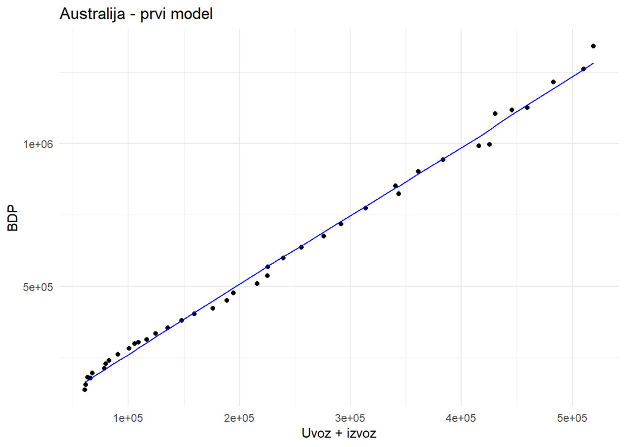

```r
ggplot(data = aus_test_data) + geom_point(aes(x = EXPORT + IMPORT, y = GDP)) + geom_line(aes(x = EXPORT + IMPORT, y = lm1$fitted.values), colour = 'blue')+ labs(x = "Uvoz + izvoz", y = "BDP", title = "Australija - prvi model") + theme_minimal()
```

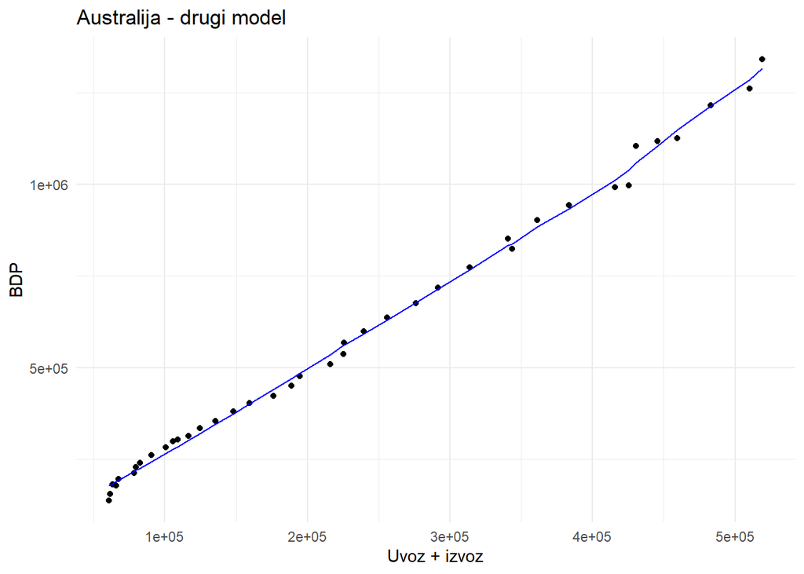

```r
ggplot(data = aus_test_data) + geom_point(aes(x = EXPORT + IMPORT, y = GDP)) + geom_line(aes(x = EXPORT + IMPORT, y = lm2$fitted.values), colour = 'blue')+ labs(x = "Uvoz + izvoz", y = "BDP", title = "Australija - drugi model") + theme_minimal()
```

Provjerit ćemo i normalnost reziduala preko QQ plotta i Kolmogorov-Smirnovljeva testa.

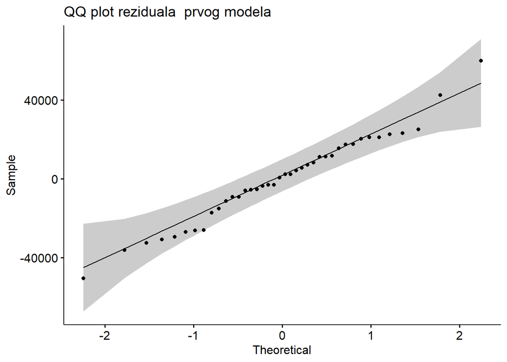

```r
ggqqplot(lm1$residuals, main = 'QQ plot reziduala  prvog modela')
```

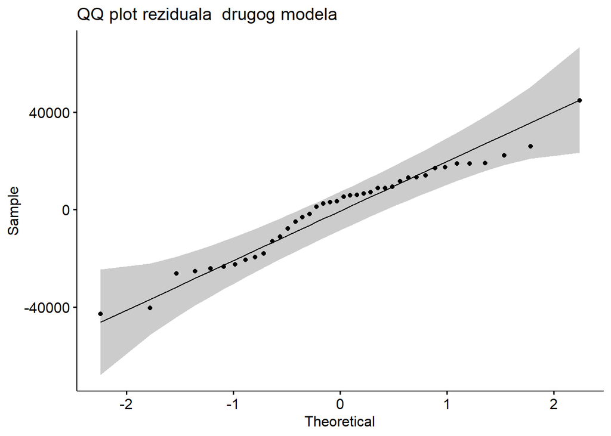

```r
ggqqplot(lm2$residuals, main = 'QQ plot reziduala  drugog modela')
```

```r
ks.test(rstandard(lm1), 'pnorm')
```

```
##
##  One-sample Kolmogorov-Smirnov test
##
## data:  rstandard(lm1)
## D = 0.081257, p-value = 0.935
## alternative hypothesis: two-sided
```

```r
ks.test(rstandard(lm2), 'pnorm')
```

```
##
##  One-sample Kolmogorov-Smirnov test
##
## data:  rstandard(lm2)
## D = 0.13312, p-value = 0.4397
## alternative hypothesis: two-sided
```

**Južna Koreja**

```r
lm.data <- sap.data %>% filter(LOCATION=="KOR")

lm1 <- lm(GDP ~ EXPORT + IMPORT + I(EXPORT^2), lm.data)
summary(lm1)
```

```
##
## Call:
## lm(formula = GDP ~ EXPORT + IMPORT + I(EXPORT^2), data = lm.data)
##
## Residuals:
##     Min      1Q  Median      3Q     Max
## -148341  -32457      67   23416   97773
##
## Coefficients:
##               Estimate Std. Error t value Pr(>|t|)
## (Intercept)  3.732e+04  2.124e+04   1.757   0.0874 .
## EXPORT       3.805e-01  3.806e-01   1.000   0.3241
## IMPORT       2.895e+00  3.733e-01   7.757 3.43e-09 ***
## I(EXPORT^2) -7.723e-07  1.576e-07  -4.899 2.05e-05 ***
## ---
## Signif. codes:  0 '***' 0.001 '**' 0.01 '*' 0.05 '.' 0.1 ' ' 1
##
## Residual standard error: 58140 on 36 degrees of freedom
## Multiple R-squared:  0.9927, Adjusted R-squared:  0.9921
## F-statistic:  1637 on 3 and 36 DF,  p-value: < 2.2e-16
```

```r
lm2 <- lm(GDP ~ IMPORT + I(IMPORT^2), lm.data)
summary(lm2)
```

```
##
## Call:
## lm(formula = GDP ~ IMPORT + I(IMPORT^2), data = lm.data)
##
## Residuals:
##     Min      1Q  Median      3Q     Max
## -146808  -32986    4556   31585  109123
##
## Coefficients:
##               Estimate Std. Error t value Pr(>|t|)
## (Intercept)  2.933e+04  2.150e+04   1.364    0.181
## IMPORT       3.356e+00  1.534e-01  21.881  < 2e-16 ***
## I(IMPORT^2) -1.031e-06  1.937e-07  -5.323 5.18e-06 ***
## ---
## Signif. codes:  0 '***' 0.001 '**' 0.01 '*' 0.05 '.' 0.1 ' ' 1
##
## Residual standard error: 59780 on 37 degrees of freedom
## Multiple R-squared:  0.9921, Adjusted R-squared:  0.9917
## F-statistic:  2321 on 2 and 37 DF,  p-value: < 2.2e-16
```

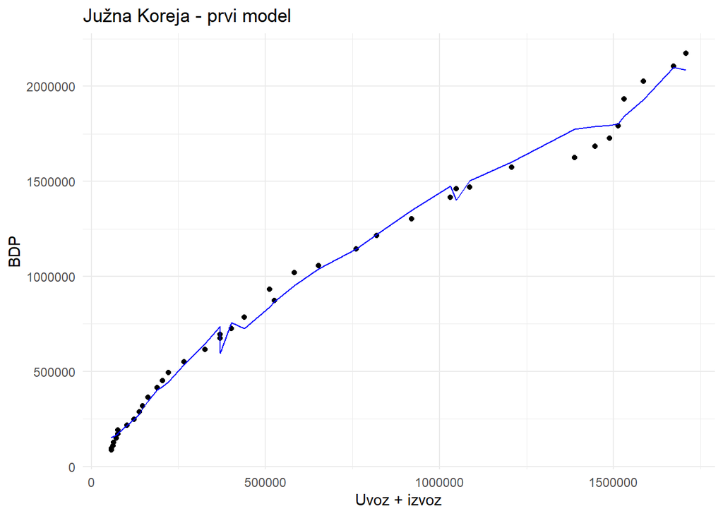

```r
ggplot(data = kor_test_data) + geom_point(aes(x = EXPORT + IMPORT, y = GDP)) + geom_line(aes(x = EXPORT + IMPORT, y = lm1$fitted.values), colour = 'blue')+ labs(x = "Uvoz + izvoz", y = "BDP", title = "Južna Koreja - prvi model") + theme_minimal()
```

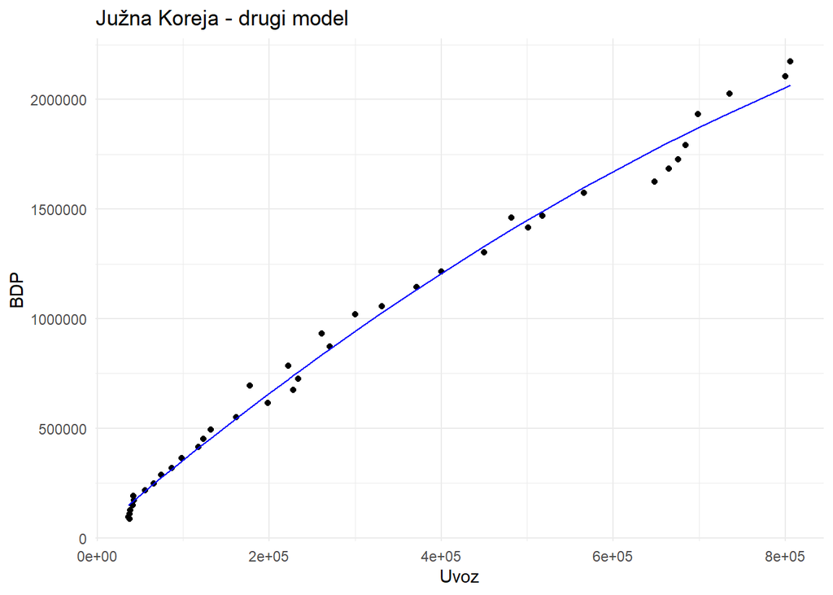

```r
ggplot(data = kor_test_data) + geom_point(aes(x = IMPORT, y = GDP)) + geom_line(aes(x = IMPORT, y = lm2$fitted.values), colour = 'blue')+ labs(x = "Uvoz", y = "BDP", title = "Južna Koreja - drugi model") + theme_minimal()
```

Provjera normalnosti reziduala za izvedene modele.

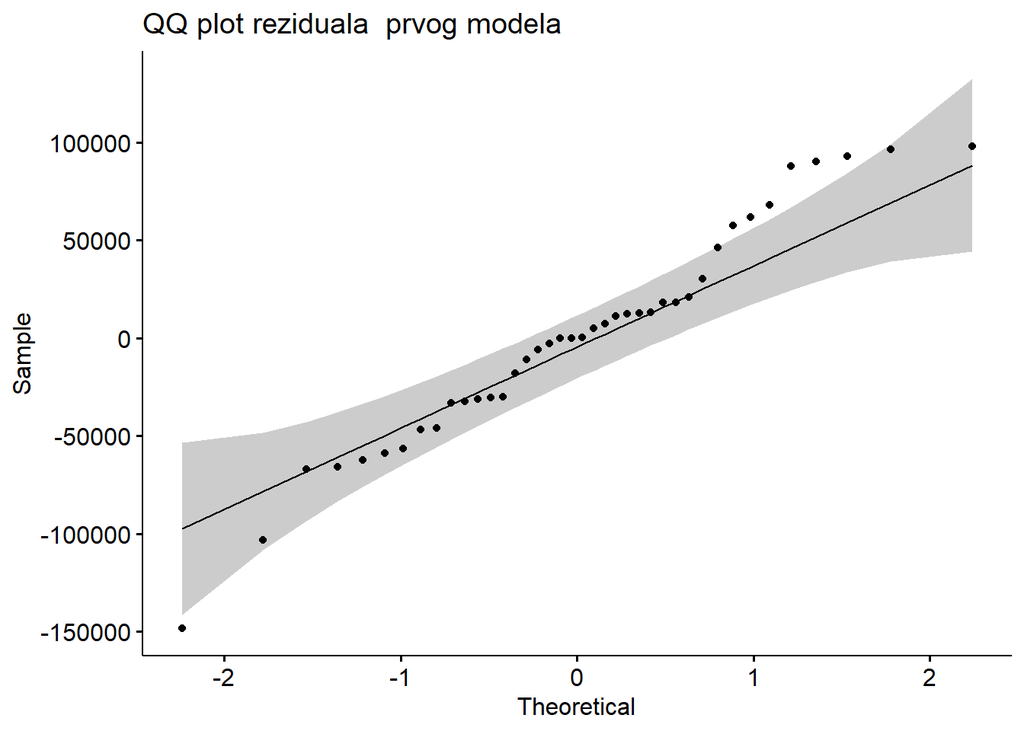

```r
ggqqplot(lm1$residuals, main = 'QQ plot reziduala  prvog modela')
```

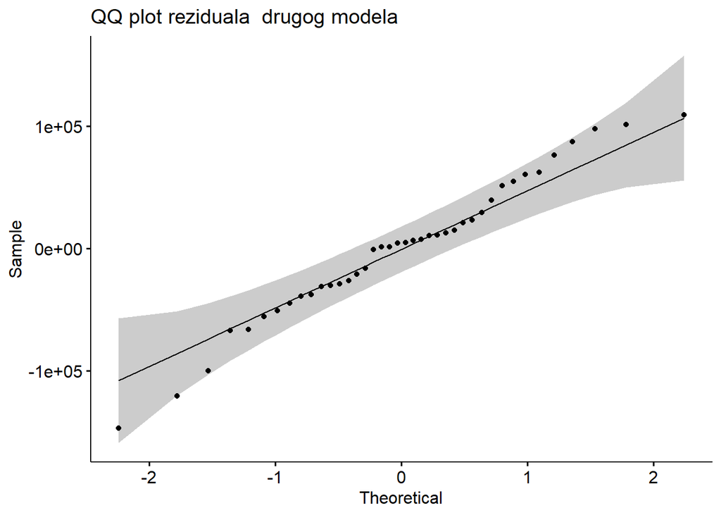

```r
ggqqplot(lm2$residuals, main = 'QQ plot reziduala  drugog modela')
```

```r
ks.test(rstandard(lm1), 'pnorm')
```

```
##
##  One-sample Kolmogorov-Smirnov test
##
## data:  rstandard(lm1)
## D = 0.10472, p-value = 0.7335
## alternative hypothesis: two-sided
```

```r
ks.test(rstandard(lm2), 'pnorm')
```

```
##
##  One-sample Kolmogorov-Smirnov test
##
## data:  rstandard(lm2)
## D = 0.094273, p-value = 0.8366
## alternative hypothesis: two-sided
```

**Norveška**

```r
lm.data <- sap.data %>% filter(LOCATION=="NOR")

lm1 <- lm(log(GDP) ~ log(EXPORT) + log(IMPORT), lm.data)
summary(lm1)
```

```
##
## Call:
## lm(formula = log(GDP) ~ log(EXPORT) + log(IMPORT), data = lm.data)
##
## Residuals:
##      Min       1Q   Median       3Q      Max
## -0.24857 -0.02910  0.01391  0.05935  0.11026
##
## Coefficients:
##             Estimate Std. Error t value Pr(>|t|)
## (Intercept) -6.49757    0.39074 -16.629  < 2e-16 ***
## log(EXPORT)  0.42592    0.08076   5.274 6.04e-06 ***
## log(IMPORT)  1.23687    0.07218  17.135  < 2e-16 ***
## ---
## Signif. codes:  0 '***' 0.001 '**' 0.01 '*' 0.05 '.' 0.1 ' ' 1
##
## Residual standard error: 0.08586 on 37 degrees of freedom
## Multiple R-squared:  0.9864, Adjusted R-squared:  0.9857
## F-statistic:  1343 on 2 and 37 DF,  p-value: < 2.2e-16
```

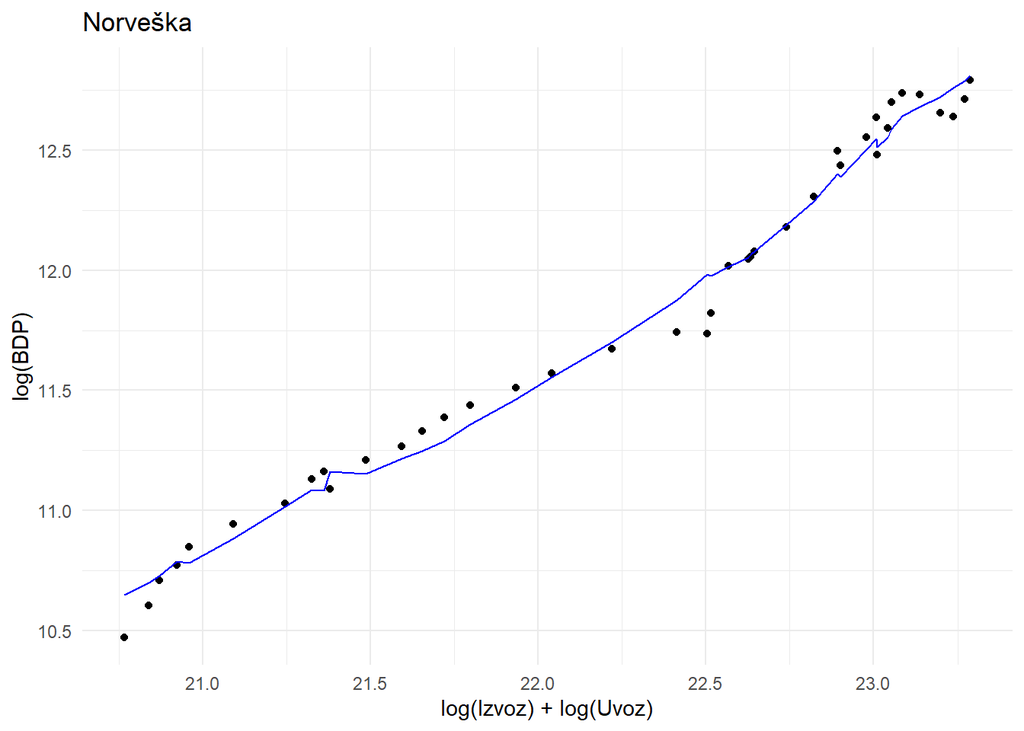

```r
ggplot(data = nor_test_data) + geom_point(aes(x = log(EXPORT) + log(IMPORT), y = log(GDP))) + geom_line(aes(x = log(EXPORT) + log(IMPORT), y = lm1$fitted.values), colour = 'blue')+ labs(x = "log(Izvoz) + log(Uvoz)", y = "log(BDP)", title = "Norveška") + theme_minimal()
```

Provjera normalnosti reziduala za izvedene modele.

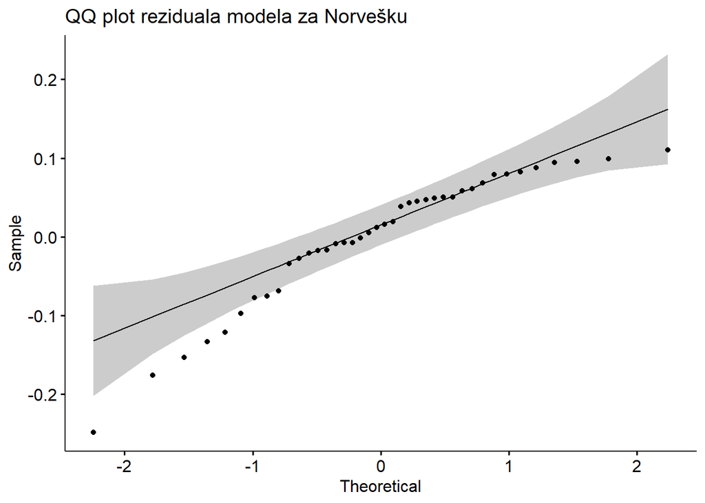

```r
ggqqplot(lm1$residuals, main = 'QQ plot reziduala modela za Norvešku')
```

```r
ks.test(rstandard(lm1), 'pnorm')
```

```
##
##  One-sample Kolmogorov-Smirnov test
##
## data:  rstandard(lm1)
## D = 0.12647, p-value = 0.5044
## alternative hypothesis: two-sided
```

**Sjedinjene Američke Države**

```r
lm.data <- sap.data %>% filter(LOCATION=="USA")

lm1 <- lm(GDP ~ EXPORT + IMPORT + I(IMPORT^2), lm.data)
summary(lm1)
```

```
##
## Call:
## lm(formula = GDP ~ EXPORT + IMPORT + I(IMPORT^2), data = lm.data)
##
## Residuals:
##     Min      1Q  Median      3Q     Max
## -911413 -290719   14381  249133 1040924
##
## Coefficients:
##              Estimate Std. Error t value Pr(>|t|)
## (Intercept) 1.234e+06  2.596e+05   4.753 3.18e-05 ***
## EXPORT      3.976e+00  5.890e-01   6.751 6.99e-08 ***
## IMPORT      2.261e+00  5.313e-01   4.256 0.000142 ***
## I(IMPORT^2) 2.226e-07  1.198e-07   1.859 0.071251 .
## ---
## Signif. codes:  0 '***' 0.001 '**' 0.01 '*' 0.05 '.' 0.1 ' ' 1
##
## Residual standard error: 421200 on 36 degrees of freedom
## Multiple R-squared:  0.9942, Adjusted R-squared:  0.9938
## F-statistic:  2075 on 3 and 36 DF,  p-value: < 2.2e-16
```

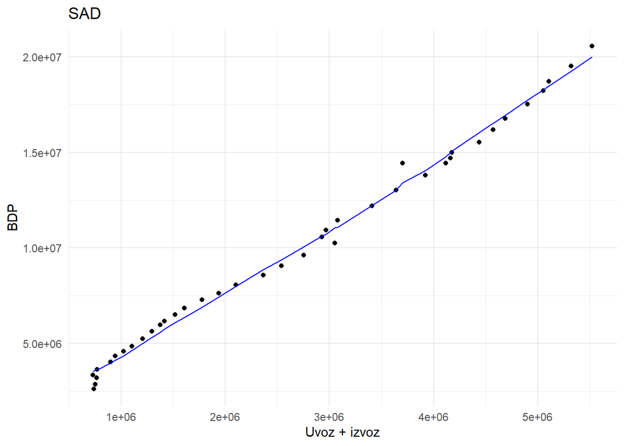

```r
ggplot(data = usa_test_data) + geom_point(aes(x = EXPORT + IMPORT, y = GDP)) + geom_line(aes(x = EXPORT + IMPORT, y = lm1$fitted.values), colour = 'blue')+ labs(x = "Uvoz + izvoz", y = "BDP", title = "SAD") + theme_minimal()
```

Provjera normalnosti reziduala za izvedene modele.

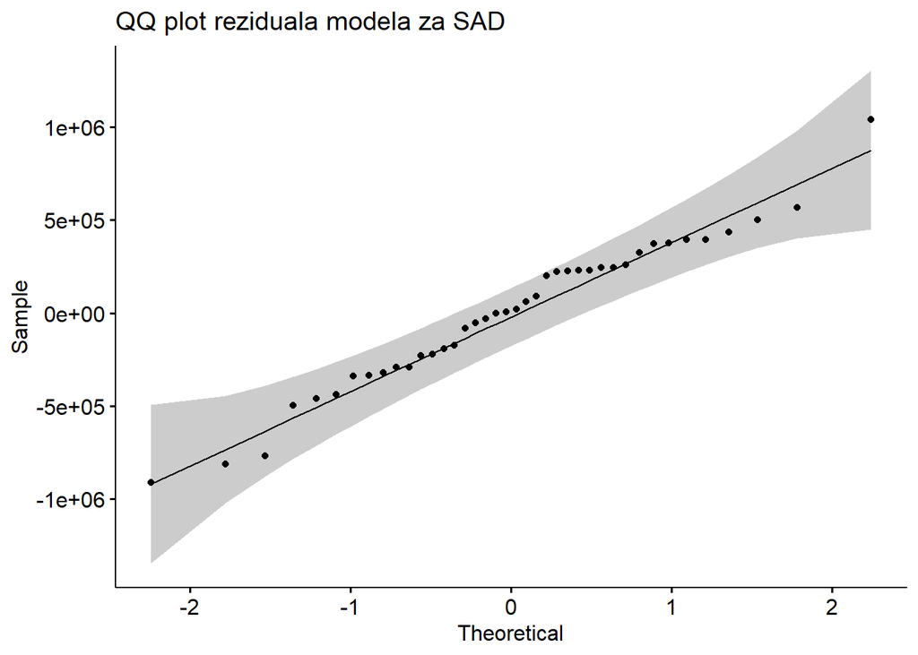

```r
ggqqplot(lm1$residuals, main = 'QQ plot reziduala modela za SAD')
```

```r
ks.test(rstandard(lm1), 'pnorm')
```

```
##
##  One-sample Kolmogorov-Smirnov test
##
## data:  rstandard(lm1)
## D = 0.11437, p-value = 0.6308
## alternative hypothesis: two-sided
```

## *Zaključak*

Gospodarstvo pojedine države određeno je iznosom uvoza i izvoza. Bruto domaći proizvod je pokazatelj jačine gospodarstva neke države, no nema smisla upoređivati apsolutne vrijedi cjelokupnog BDP-a jer možemo dobiti krivu sliku o jačini gospodarstva. BDP se zato najčešće prikazuje po glavi stavnovnika. Nadalje, pokazali smo kako se skoro za sve ispitane države BDP može aproksimirati linearnom regresijom pri čemu su regresori vrijednosti uvoza i izvoza te države. Konačno, pokazali smo kako s razinom značajnosti od 5% ne možemo pokazati jednakost rasta BDP-a i BDP-a per capita za sve ispitane države, kao i jednakost rasta izvoza i uvoza ispitanih država.

U izradi ovog rada uvelike nam je pomogao ovaj motivirajući video: https://www.youtube.com/watch?v=BvWefB4NGGI